# Customs and ‘Border’ Patrol

Will Lowe

2/11/2018

Vox [reminds us](https://www.vox.com/policy-and-politics/2018/2/9/16974510/border-patrol-greyhound-bus-amtrak-train) that that US constitutional protections are [weaker](https://www.aclu.org/other/constitution-100-mile-border-zone) within 100 miles of a US border. The consequences are, I think, quite surprising. For example, a majority of states are either partly or entirely inside this ‘border’ zone. (I borrowed these scare-quotes from the ACLU).

As a non-American, I don’t really expect constitutional protections to be much use to me, and as a non-lawyer I don’t really have anything terribly insightful to say about them either. However, I do write a lot of R so this seems like a good excuse to demonstrate some spatial analysis. So fire up an RStudio and let’s dig into the data.

We’re going use `sf`, a nice R package for spatial data analysis, and some helpers

```r
library(sf)
library(dplyr)
library(ggplot2)
library(units)
library(readr)
```

`dplyr` and `ggplot2` are from the tidyverse and need no introduction.  
And `units` is useful for converting units. We’ll use it for when we want to translate square kilometers into American.

## US Shapefiles

Let’s first pull some recent US state shapefiles from the Census Bureau and unpack them locally. These are simplified, and are not suitable for fine-grained areal analysis, but we can get an idea of things from them without much wait.

```r
dir.create("data") # a place to put the shapefiles
download.file("http://www2.census.gov/geo/tiger/GENZ2016/shp/cb_2016_us_state_20m.zip",
              "data/cb_2016_us_state_20m.zip")
unzip("data/cb_2016_us_state_20m.zip", exdir = "data")
```

For the purposes of figuring out what ‘100 miles from a US border’ means, we’ll want these polygons in a projection that makes *buffering* easy. Here’s a fairly standard projection, but you could choose another.

```r
us_longlat <- st_read("./data/cb_2016_us_state_20m/cb_2016_us_state_20m.shp")
us <- st_transform(us_longlat, "+init=epsg:26978")
```

These shapes are in meters, so that’s where we’ll keep them, and we’ll need to know that 100 miles in meters is

```r
meters <- 160934.4
```

## Identifying the ‘Border’ Zone

First we’ll merge all the states and territories together to get a lump of US landmass.

```r
us_outline <- st_union(us)
```

then use buffering to get boundaries for the part of the country 100 miles inside the border - the area in which CBP have reduced powers. The ‘border’ zone is the region outside this region but inside the national borders

```r
not_border_zone <- st_buffer(us_outline, dist = -meters) # negative to go inland
border_zone <- st_difference(us_outline, not_border_zone)
```

How big is the ‘border’ zone compared to the whole country?

```r
border_zone_area <- st_area(border_zone)
not_border_zone_area <- st_area(not_border_zone)

set_units(border_zone_area, miles^2) # Translate to American
```

```
1450587 miles^2
```

```r
set_units(not_border_zone_area, miles^2)
```

```
2394155 miles^2
```

This means that the proportion of US landmass that is in a ‘border’ zone is

```r
prop_us_covered <- border_zone_area / (border_zone_area + not_border_zone_area)
prop_us_covered
```

```
0.3772912 1
```

Quite a bit. Big country - big borders…

## ‘Border’ States

Now let’s compute the proportion of each state that is in the ‘border’ zone. That’s just the intersection of the landmass and the ‘border’ zone.

```r
overlaps <- st_intersection(us, border_zone)
```

The intersection doesn’t include states that have no ‘border’ zone so we’ll tidy it up into a form that’s easy to plot.

```r
ov_df <- data_frame(NAME = overlaps$NAME, AREA = st_area(overlaps))
us_df <- data_frame(NAME = us$NAME, AREA = st_area(us))
covered <- left_join(us_df, ov_df, by = "NAME") %>%
  mutate(prop = ifelse(is.na(AREA.y), 0, AREA.y / AREA.x),
         NAME = factor(NAME, levels = NAME[order(prop)])) %>%
  arrange(desc(prop))
```

I’ve sorted the state and territory names according to their ‘border’ proportions so that ggplot will behave itself.

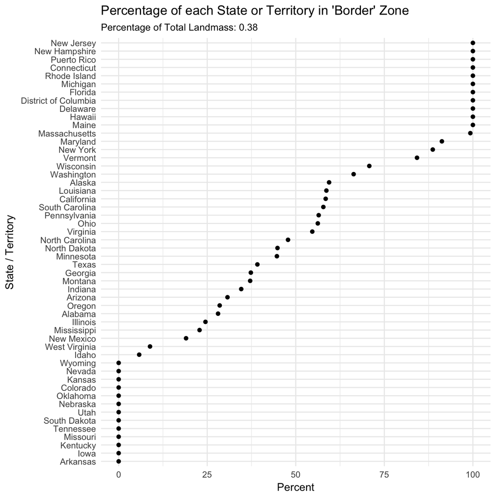

```r
ggplot(covered, aes(x = NAME, y = 100 * prop)) +
  geom_point() +
  coord_flip() +
  labs(y = "Percent",
       x = "State / Territory",
       title = "Percentage of each State or Territory in 'Border' Zone",
       subtitle = sprintf("Percentage of Total Landmass: %.2f", prop_us_covered)) +
  theme_minimal()
```

## Maps of the ‘Border’

Let’s see what this border looks like on a map. For the sake of readability, we’ll do *two* maps: one map for the contiguous United States - that means everything in the Census shapefile except for Puerto Rico, Alaska, and Hawaii - and another map for Alaska. Puerto Rico and Hawaii are small enough that they’re all ‘border’, so the plot is not so interesting. (But feel free to try it).

```r
not_contiguous_us <- c("Puerto Rico", "Alaska", "Hawaii")

us_filt <- filter(us, !(NAME %in% not_contiguous_us))
us_outline <- st_union(us_filt) # contiguous outline
not_border_zone <- st_buffer(us_outline, dist = -meters) # mainland outline 100m in
border_zone <- st_difference(us_outline, not_border_zone)
```

This time we’ll use `sf`’s built in plot command. This can be done in ggplot2 but not in the version that’s currently on CRAN, so we’ll keep it simple. I’ve added graticules - the projection lines behind the country - because it’s a cool word that I learned this afternoon while looking up how to do this.

## The ‘Border’ in the Contiguous United States

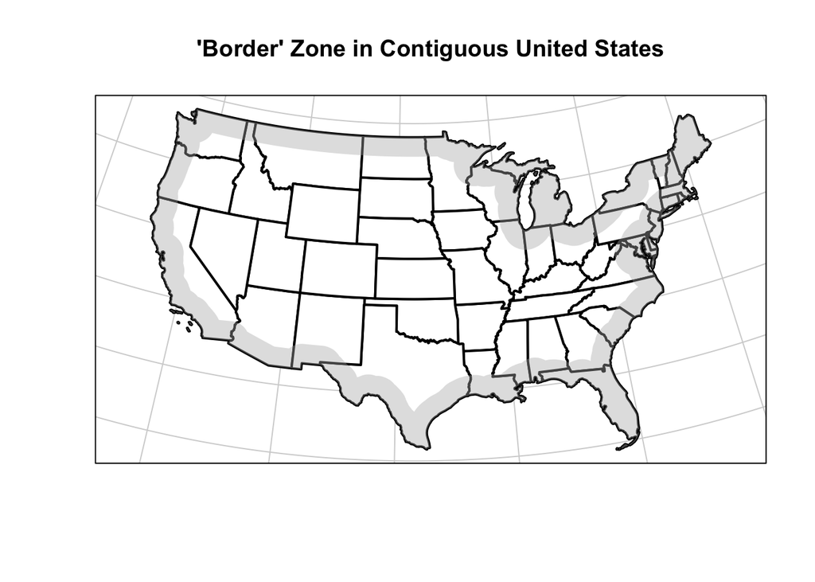

```r
plot(st_geometry(us_filt),  lwd = 2,
     main = "'Border' Zone in Contiguous United States",
     graticule = TRUE, col = "white", col_graticule = "lightgrey")
plot(border_zone, lty = "blank", col = rgb(0.7, 0.7, 0.7, 0.4), add = TRUE)
```

## The ‘Border’ in Alaska

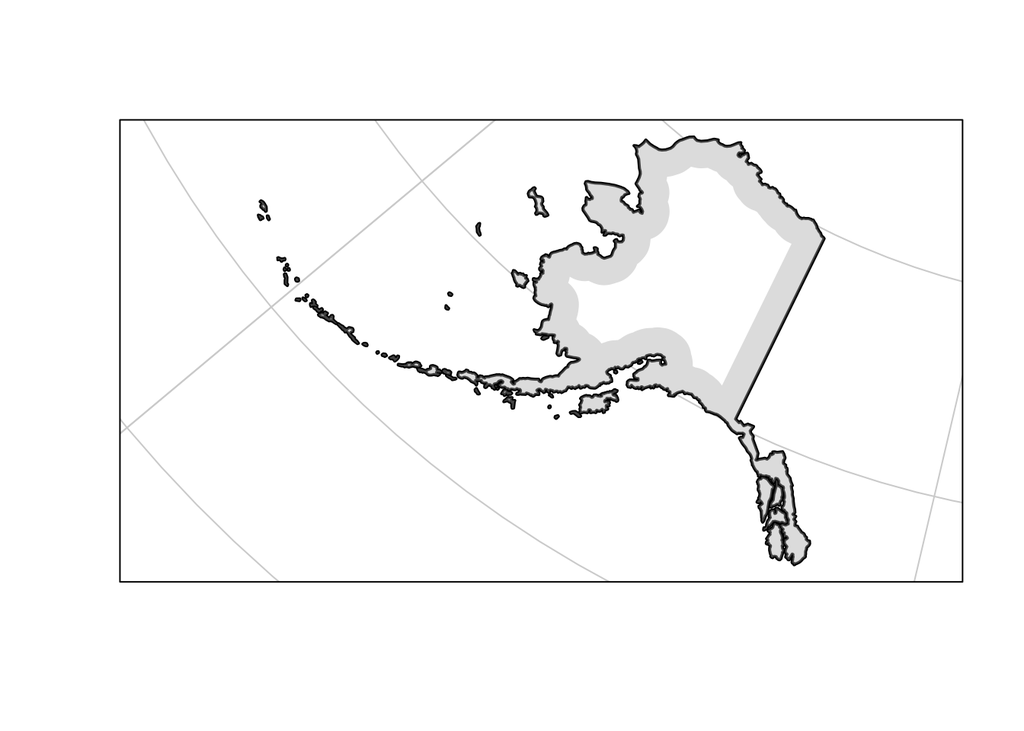

```r
us_filt <- filter(us, NAME == "Alaska")

us_outline <- st_union(us_filt) # Alaska outline
not_border_zone <- st_buffer(us_outline, dist = -meters) # Alaska outline 100m in
border_zone <- st_difference(us_outline, not_border_zone)

plot(st_geometry(us_filt),  lwd = 2,
     graticule = TRUE, col = "white", col_graticule = "lightgrey")
plot(border_zone, lty = "blank", col = rgb(0.7, 0.7, 0.7, 0.4), add = TRUE)
```

And we’re done.